# Reproducible Research: Peer Assessment 1

## Loading and preprocessing the data

1. Load the data (i.e. read.csv())
2. Process/transform the data (if necessary) into a format suitable for your analysis

```r
actdata <- read.csv("activity.csv", na.strings = "NA", stringsAsFactors = FALSE)
actdata$date <- as.Date(actdata$date)
```

## What is mean total number of steps taken per day?

1. Calculate the total number of steps taken per day
2. Make a histogram of the total number of steps taken each day
3. Calculate and report the mean and median total number of steps taken per day

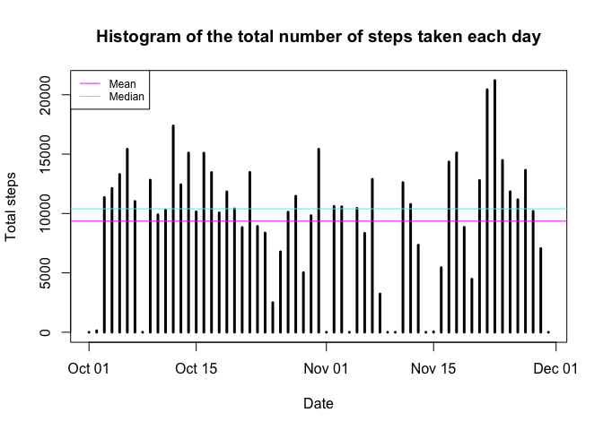

```r
library(dplyr)
actdata <- tbl_df(actdata)
actdata <- group_by(actdata, date)
steptotal <- summarize(actdata, Total_steps = sum(steps, na.rm = TRUE))
plot(steptotal$date, steptotal$Total_steps,
     type = "h",
     lwd = 3,
     main = "Histogram of the total number of steps taken each day",
     xlab = "Date",
     ylab = "Total steps")
abline(h = mean(steptotal$Total_steps), col = "magenta")
abline(h = median(steptotal$Total_steps), col = "cyan")
legend("topleft", legend = c("Mean", "Median"),
       col = c("magenta", "cyan"), lty = 1, cex = 0.75)
```

```r
print(paste("The mean of total number of steps taken per day is", mean(steptotal$Total_steps)))
print(paste("The median of total number of steps taken per day is", median(steptotal$Total_steps)))
```

```
## [1] "The mean of total number of steps taken per day is 9354.22950819672"
## [1] "The median of total number of steps taken per day is 10395"
```

## What is the average daily activity pattern?

1. Make a time series plot (i.e. type = “l”) of the 5-minute interval (x-axis) and the average number of steps taken, averaged across all days (y-axis)
2. Which 5-minute interval, on average across all the days in the dataset, contains the maximum number of steps?

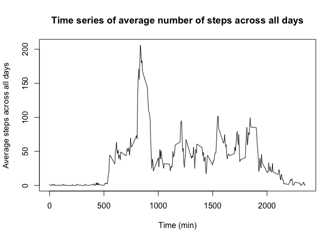

```r
ungroup(actdata)
actdata <- group_by(actdata, interval)
stepaverage <- summarize(actdata, Average_steps = mean(steps, na.rm = TRUE))
plot(stepaverage$interval, stepaverage$Average_steps,
     type = "l",
     main = "Time series of average number of steps across all days",
     xlab = "Time (min)",
     ylab = "Average steps across all days")
```

```r
maxinterval <- stepaverage[which.max(stepaverage$Average_steps), 1]
print(paste(maxinterval, "interval contains the maximum number of steps."))
```

```
## [1] "835 interval contains the maximum number of steps."
```